# Capstone USpollution

```r
names(uspollution) <- tolower(names(uspollution))
names(uspollution) <- stringr::str_replace_all(names(uspollution), pattern = " ",
                                                                  replacement = "_")

names(uspollution)
```

```
##  [1] "x1"                "state_code"        "county_code"
##  [4] "site_num"          "address"           "state"
##  [7] "county"            "city"              "date_local"
## [10] "no2_units"         "no2_mean"          "no2_1st_max_value"
## [13] "no2_1st_max_hour"  "no2_aqi"           "o3_units"
## [16] "o3_mean"           "o3_1st_max_value"  "o3_1st_max_hour"
## [19] "o3_aqi"            "so2_units"         "so2_mean"
## [22] "so2_1st_max_value" "so2_1st_max_hour"  "so2_aqi"
## [25] "co_units"          "co_mean"           "co_1st_max_value"
## [28] "co_1st_max_hour"   "co_aqi"
```

Het omzetten van de data naar een tidy dataframe

```r
uspollution_tidy <- uspollution %>% mutate(day = format(date_local, "%d"),
                                           month = format(date_local, "%m"),
                                           year = format(date_local, "%Y")) %>%
 group_by (day, month, year)
```

Verwijderen van voor de opdracht niet gebruikte data

```r
uspollution_clean <- uspollution_tidy %>% select(state, county, city, date_local, no2_aqi, o3_aqi, so2_aqi, co_aqi)
```

Het verwijderen van alle NA’s in de dataset

```r
uspollution_no_na <- uspollution_clean %>%
  na.omit()

summary(uspollution_no_na)
```

```
##      day               month               year
##  Length:436876      Length:436876      Length:436876
##  Class :character   Class :character   Class :character
##  Mode  :character   Mode  :character   Mode  :character
##
##
##
##     state              county              city
##  Length:436876      Length:436876      Length:436876
##  Class :character   Class :character   Class :character
##  Mode  :character   Mode  :character   Mode  :character
##
##
##
##    date_local            no2_aqi          o3_aqi          so2_aqi
##  Min.   :2000-01-01   Min.   :  0.0   Min.   :  0.00   Min.   :  0.000
##  1st Qu.:2004-11-23   1st Qu.: 12.0   1st Qu.: 25.00   1st Qu.:  1.000
##  Median :2009-02-04   Median : 23.0   Median : 33.00   Median :  3.000
##  Mean   :2008-10-14   Mean   : 23.9   Mean   : 36.05   Mean   :  7.117
##  3rd Qu.:2012-11-06   3rd Qu.: 33.0   3rd Qu.: 42.00   3rd Qu.:  9.000
##  Max.   :2016-05-31   Max.   :132.0   Max.   :218.00   Max.   :200.000
##      co_aqi
##  Min.   :  0.000
##  1st Qu.:  2.000
##  Median :  5.000
##  Mean   :  5.996
##  3rd Qu.:  8.000
##  Max.   :201.000
```

Boxplot van alle Air Quality Indexes can alle geteste staten.

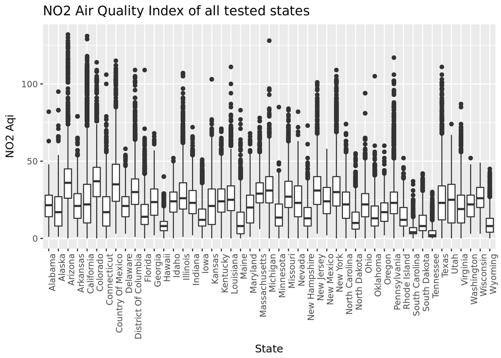

```r
plot_us_no2 <- ggplot(data = uspollution_no_na, aes(x = state, y = no2_aqi)) +
  geom_boxplot() +
  theme(axis.text.x=element_text(angle=90, hjust=1)) +
  labs(title="NO2 Air Quality Index of all tested states",
       x ="State",
       y = "NO2 Aqi")

plot_us_o3 <- ggplot(data = uspollution_no_na, aes(x = state, y = o3_aqi)) +
  geom_boxplot() +
  theme(axis.text.x=element_text(angle=90, hjust=1)) +
  labs(title="O3 Air Quality Index of all tested states",
       x ="State",
       y = "O3 Aqi")

plot_us_so2 <- ggplot(data = uspollution_no_na, aes(x = state, y = so2_aqi)) +
  geom_boxplot() +
  theme(axis.text.x=element_text(angle=90, hjust=1)) +
  labs(title="SO2 Air Quality Index of all tested states",
       x ="State",
       y = "SO2 Aqi")

plot_us_co <- ggplot(data = uspollution_no_na, aes(x = state, y = co_aqi)) +
  geom_boxplot() +
  theme(axis.text.x=element_text(angle=90, hjust=1)) +
  labs(title="CO Air Quality Index of all tested states",
       x ="State",
       y = "CO Aqi")


plot_us_no2
```

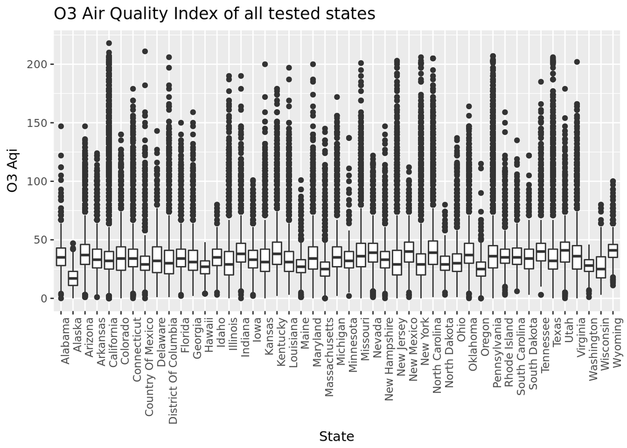

```r
plot_us_o3
```

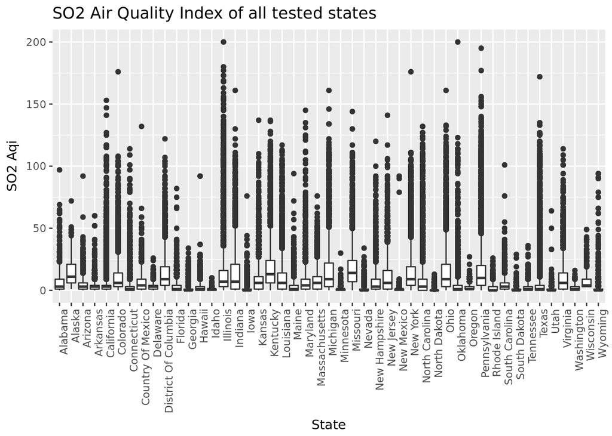

```r
plot_us_so2
```

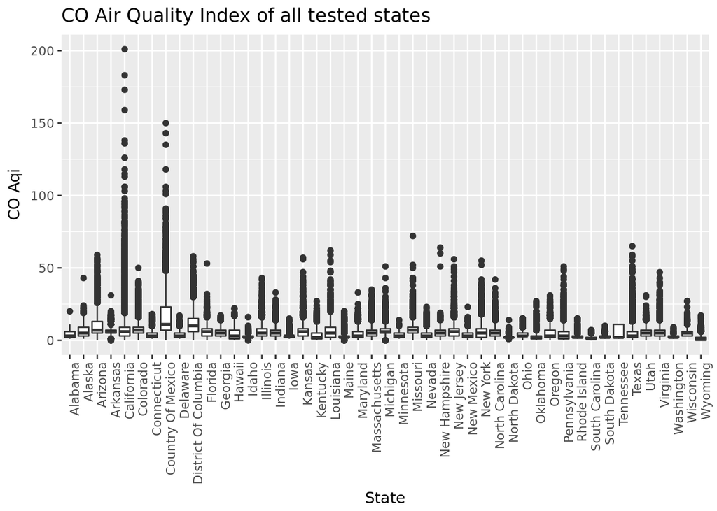

```r
plot_us_co
```

Plot met de alle Air Quality Indexes van de Country of Mexico.

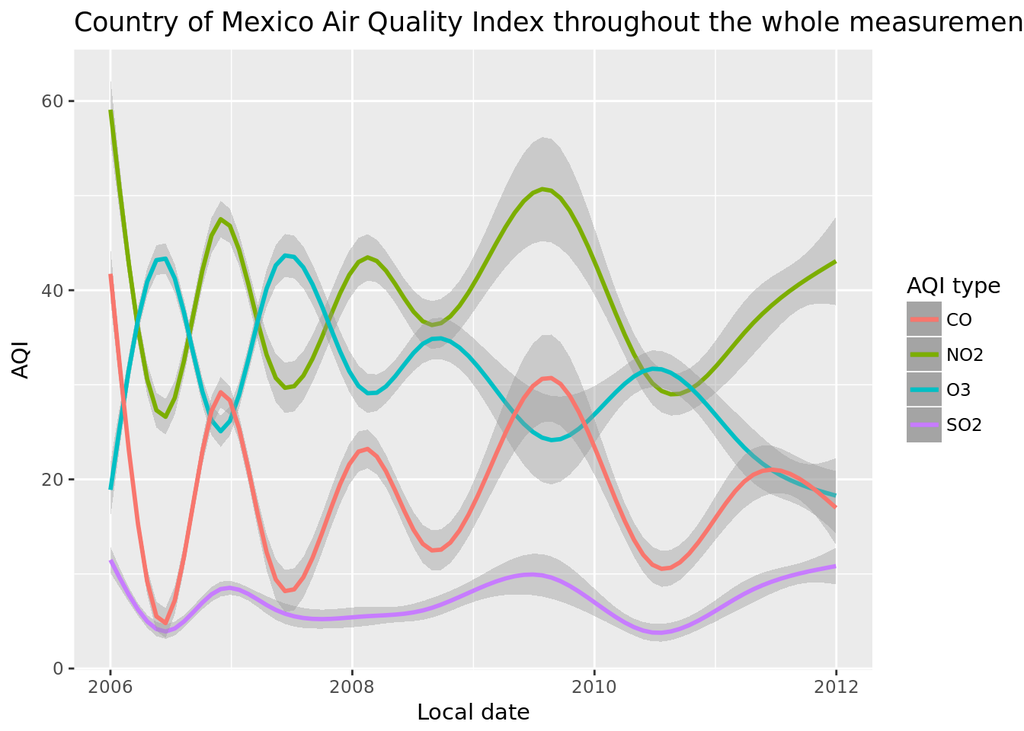

```r
uspollution_com <- uspollution_no_na %>% filter(state == 'Country Of Mexico')

plot_com <- ggplot(data = uspollution_com) +
  geom_smooth(aes(x = date_local, y = no2_aqi, colour = "NO2")) +
  geom_smooth(aes(x = date_local, y = o3_aqi, colour = "O3")) +
  geom_smooth(aes(x = date_local, y = so2_aqi, colour = "SO2")) +
  geom_smooth(aes(x = date_local, y = co_aqi, colour = "CO")) +
  labs(title="Country of Mexico Air Quality Index throughout the whole measurement time",
        x ="Local date", y = "AQI", colour = "AQI type")

plot_com
```

Plot met de Air Quality Indexes voor NO2 en CO voor alle geteste steden in de Country of Mexico.

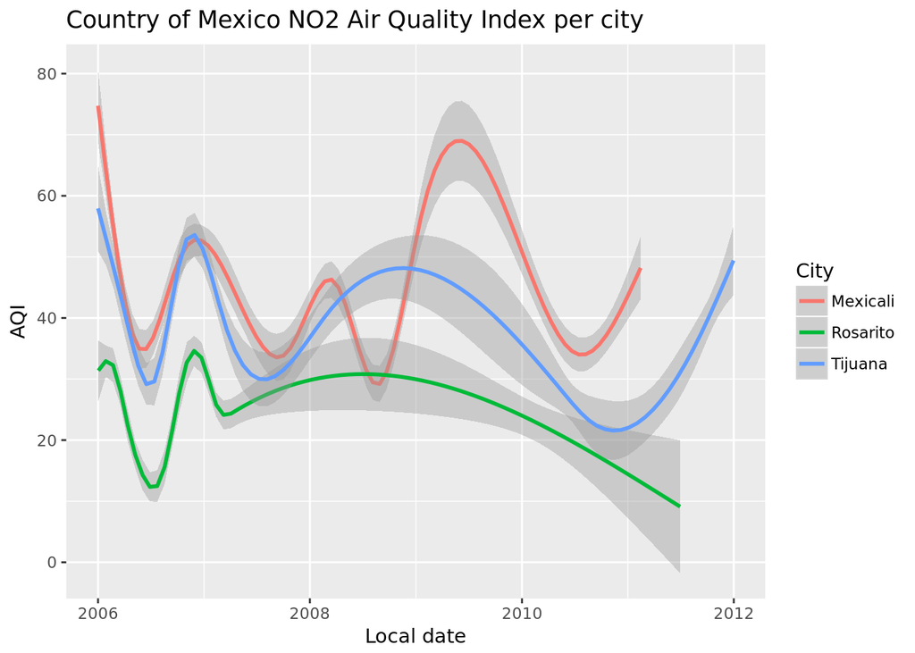

```r
plot_com_no2 <- ggplot(data = uspollution_com) +
  geom_smooth(aes(x = date_local, y = no2_aqi, colour = city)) +
  labs(title="Country of Mexico NO2 Air Quality Index per city",
        x ="Local date", y = "AQI", colour = "City", colour = "City")
plot_com_co <- ggplot(data = uspollution_com) +
  geom_smooth(aes(x = date_local, y = co_aqi, colour = city)) +
  labs(title="Country of Mexico CO Air Quality Index per city",
        x ="Local date", y = "AQI", colour = "City", colour = "City")
plot_com_no2
```

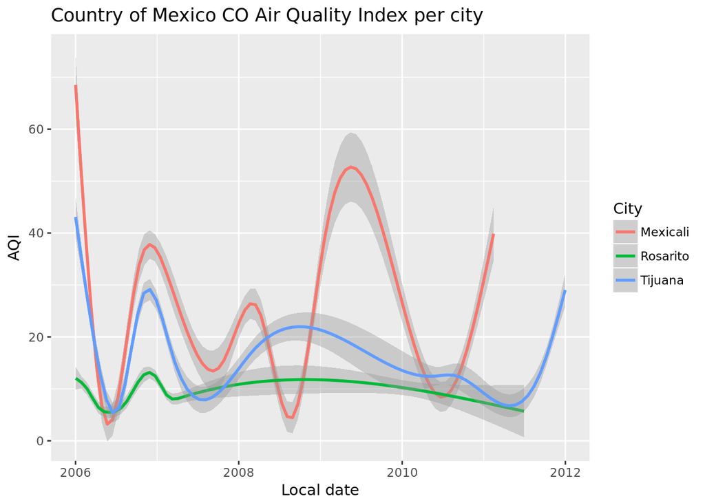

```r
plot_com_co
```